# Part II - FordGoBike User Behaviour in San Francisco Bay Area

## by Zainab Akanji

## Investigation Overview

In this investigation, I aimed to look at the behaviour of the two FordGoBike user types and different gender types in San Francisco Bay Area. Summary of key insights: I wrangled the data preliminarily and removed outliers; I explored the individual variables of interest and I found out that;

Most trips were between 0 1nd 15 minutes with a peak at 10 minutes

Most users are subscribers

Most bike users are between the ages of 25-40years with a peak age at 30years.

The highest number of trips are taken on Thursdays

The highest number of trips are taken by 8a.m and 5p.m which corresponds to the beginning and end of work hours respectively.

Then I moved on to perform Bivariate Explortation and analysis showed that;

Users between the ages 25-35years take the most trips that are less than 20 minutes

Customers take longer bike trips

Subscribers take most of their trips during the weekday and Customers take most of their trips during weekends

Then on Multivariate Exploration;

There is no significant relationship between age, bike duration and gender.

Female customers take the longest of trips

Male and Female Subscribers are most active by the beginning and end of work hours(i.e 8a.m and 5p.m) while male and female customers take their most trips between 7a.m and 10p.m since customers tend to ride mostly on weekends.

## Dataset Overview

There are 174952 bike observations in the dataset with 16 features. Some variables are numeric in nature, but user_type and member_gender are qualitative in nature. There were 183412 observations originally but missing values were dropped.

## Distribution of Trip Duration

Most bike trips were between 0 to 15 minutes with peak at 10 minutes. This could be due to short distances taken between the respective start and end stations

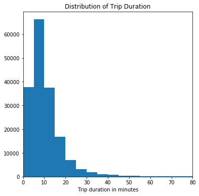

## Counts of the two user types

The question I want to answer in this practice is that "Are there more subscribers than customers?" To answer this question, I visualized a countplot that shows most users are subscribers.

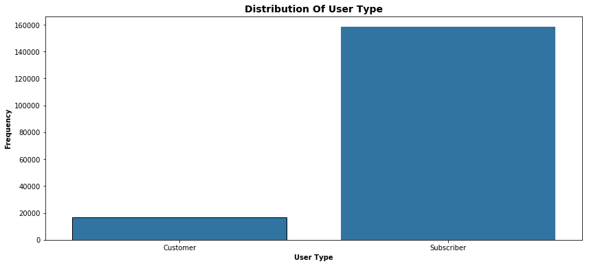

## Member gender frequency

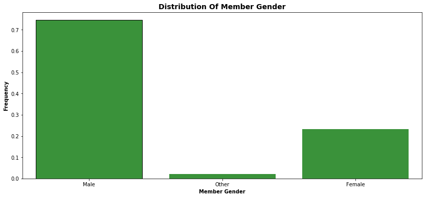

## Trip Distribution of user types

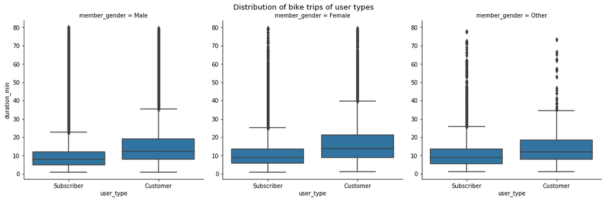

## Distribution of bike trips of user types of different gender at different hours of the day

Male and Female Subscribers are most active by the beginning and end of work hours(i.e 8a.m and 5p.m) while male and female customers take their most trips between 7a.m and 10p.m since customers tend to ride mostly on weekends.

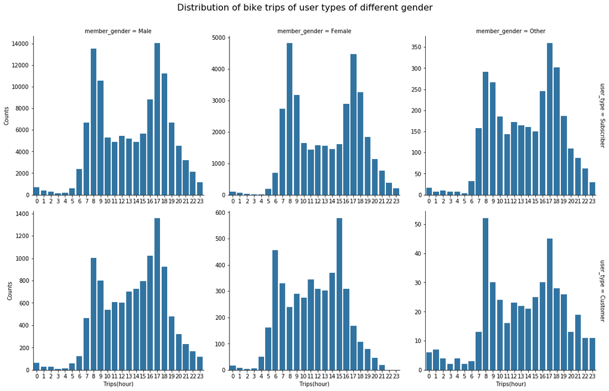